# Introduction

In this small project we will take a look at Seattle weather dataset from Kaggle to extract important features and use them to test functionality of Recurrent Neural Network.

#### Main objective

Build a model using PyTorch library that predicts temperature for the next day.

#### Process includes:

1. **Data**  
   1.1 Overview  
   1.2 Visualization  
   1.3 Data seasonality  
   1.4 Granger causality
2. **Preparing Dataset**  
   2.1 Load data  
   2.2 Feature scaling  
   2.3 Train / test split  
   2.4 Data loader
3. **Building Model**  
   3.1 Class RNN  
   3.2 Training  
   3.3 Testing  
   3.4 Second model  
   3.5a Cross-validation for single feature  
   3.5b Cross-validation for multiple features  
   3.6 Comparison
4. **Conclusion**

#### Setup

Matplotlib color scheme and random seeds.

```python
import matplotlib.pyplot as plt

WHITE_MID = '#b5b5b5'
GREY_DARK = '#141414'

plt.rcParams['figure.facecolor'] = GREY_DARK
plt.rcParams['text.color'] = WHITE_MID
plt.rcParams['axes.facecolor'] = GREY_DARK
plt.rcParams['axes.edgecolor'] = WHITE_MID
plt.rcParams['axes.labelcolor'] = WHITE_MID
plt.rcParams['axes.titlecolor'] = WHITE_MID

plt.rcParams['grid.color'] = WHITE_MID
plt.rcParams['grid.linestyle'] = '--'
plt.rcParams['grid.linewidth'] = 0.5
plt.rcParams['axes.grid'] = True

plt.rcParams['axes.linewidth'] = 1
plt.rcParams['xtick.color'] = WHITE_MID
plt.rcParams['ytick.color'] = WHITE_MID
plt.rcParams['legend.edgecolor'] = WHITE_MID
plt.rcParams['legend.labelcolor'] = WHITE_MID
```

Random seeds, cuda and warnings.

```python
import numpy as np
import torch
import random
import warnings

warnings.filterwarnings("ignore")

seed = 42

random.seed(seed)
np.random.seed(seed)

# the model is not reproducible probably due to training on GPU (CUDA)
torch.manual_seed(seed)
if torch.cuda.is_available():
    torch.cuda.manual_seed(seed)
    torch.cuda.manual_seed_all(seed)
torch.backends.cudnn.deterministic = True
torch.backends.cudnn.benchmark = False

device = torch.device("cuda:0" if torch.cuda.is_available() else "cpu")
device
```

```
device(type='cuda', index=0)
```

# II - Preparing Dataset

#### 2.1 - Load data

```python
import pandas as pd

df = pd.read_csv('../datasets/weather-processed.csv')
df
```

|  | precipitation | wind | temp_avg |
| --- | --- | --- | --- |
| 0 | 0.0 | 4.7 | 8.90 |
| 1 | 10.9 | 4.5 | 6.70 |
| 2 | 0.8 | 2.3 | 9.45 |
| 3 | 20.3 | 4.7 | 8.90 |
| 4 | 1.3 | 6.1 | 5.85 |
| ... | ... | ... | ... |
| 1456 | 8.6 | 2.9 | 3.05 |
| 1457 | 1.5 | 1.3 | 3.35 |
| 1458 | 0.0 | 2.6 | 3.90 |
| 1459 | 0.0 | 3.4 | 2.30 |
| 1460 | 0.0 | 3.5 | 1.75 |

1461 rows × 3 columns

#### 2.2 - Feature scaling

Using **MinMaxScaler** from sklearn.

```python
from sklearn.preprocessing import MinMaxScaler
scaler = MinMaxScaler()
features = ['precipitation', 'temp_avg', 'wind']

df.loc[:, features] = scaler.fit_transform(df[features]) # applying scaled features to numeric features

df.describe()
```

|  | precipitation | wind | temp_avg |
| --- | --- | --- | --- |
| count | 1461.000000 | 1461.000000 | 1461.000000 |
| mean | 0.054194 | 0.312213 | 0.529080 |
| std | 0.119503 | 0.158003 | 0.196657 |
| min | 0.000000 | 0.000000 | 0.000000 |
| 25% | 0.000000 | 0.197802 | 0.378689 |
| 50% | 0.000000 | 0.285714 | 0.516393 |
| 75% | 0.050089 | 0.395604 | 0.688525 |
| max | 1.000000 | 1.000000 | 1.000000 |

#### 2.3 - Train / test split

```python
train_size = int(len(df) * 0.7) + 1
test_size = int(len(df) * 0.3)

print(
    f"{f"train size":>12}: {train_size}",
    f"{f"test size":>12}: {test_size}",
    len(df) == train_size + test_size,
    sep='\n'
)
```

```
  train size: 1023
   test size: 438
True
```

```python
df_train = df[:train_size]
df_test = df[train_size:]
```

We're going to pass sequenced data with length of n days per sequence.  
Knowing that, we have to make sure that our datasets are divisible by n.  
With *sequence_len* parameter we can adjust length of sequence in days (1 day, week, month) and test how it affects models predictions.  
Despite this there's no enough data to test this model on longer sequences like month, so I chose one week.

```python
sequence_len = 7

df_train = df_train[:(len(df_train) // sequence_len) * sequence_len]
df_test = df_test[:(len(df_test) // sequence_len) * sequence_len]

print(
    len(df_train),
    len(df_test), sep='\n'
)
```

```
1022
434
```

Convert each data split to numpy, so we're able to pass it to torch.

```python
df_train_torch = df_train.to_numpy()
df_train_torch = torch.tensor(df_train_torch)

df_test_torch = df_test.to_numpy()
df_test_torch = torch.tensor(df_test_torch)
df_test_torch[:7]
```

```
tensor([[0.2093, 0.2967, 0.5885],
        [0.0179, 0.4725, 0.5803],
        [0.5725, 0.5055, 0.5721],
        [0.1682, 0.4615, 0.4967],
        [0.0733, 0.3077, 0.5066],
        [0.1091, 0.5495, 0.5344],
        [0.0268, 0.5055, 0.4623]], dtype=torch.float64)
```

#### 2.4 - Data loader

To predict temperature based on features from past n days,  
we have to reshape our data split sets to return specific sequences.  
Each sequence containing data from 7 days, where:  
X - temp_avg from first n days  
y - same feature, but we take just the last day

```python
from torch.utils.data import TensorDataset, DataLoader

def sequence_dataset(dataset, batch_size, extra_features=False):

    x, y = [], []

    for i in range(0, len(dataset) - sequence_len, sequence_len):

        # if extra_features = True, then x = [precipitation, wind, temp_avg], y = temp_avg
        # if extra_features = False, then x = temp_avg, y = temp_avg
        if extra_features:
            week = dataset[i: i + sequence_len, :] # take precipitation, wind and temperature (:)
            week_input = week[:sequence_len-1] # trim to n days
            week_target = week[-1, 2] # take last day
        else:
            week = dataset[i: i + sequence_len, 2] # take just the temperature (2)
            week_input = week[:sequence_len-1] # trim to n days
            week_target = week[-1] # take last day

        x.append(week_input)
        y.append(week_target)

    # covert to tensor dataset
    tensor_dataset = TensorDataset(torch.tensor(np.asarray(x)),
                                   torch.tensor(np.asarray(y)))

    # covert to data_loader
    data_loader = DataLoader(tensor_dataset, batch_size=batch_size, shuffle=True, drop_last=True)

    return data_loader
```

```python
batch_size = 8
train_loader = sequence_dataset(df_train_torch, batch_size=batch_size)
test_loader = sequence_dataset(df_test_torch, batch_size=batch_size)
```

```python
for batch in train_loader:
    input, target = batch
    print(input[0], target[0], sep='\n')
    break
```

```
tensor([0.3344, 0.3803, 0.3623, 0.3787, 0.3246, 0.2885], dtype=torch.float64)
tensor(0.3066, dtype=torch.float64)
```

# III - Building Model

#### 3.1 - Class RNN

With PyTorch we are able to build simple RNN with Long Short-Term Memory layers by simply attaching *nn.LSTM()* with specific factors in it.  
The **init** function first initializes the LSTM and fully connected layers.  
*forward()* passes our input x to the rnn network then fully connects it to finally return last value from the output.

```python
from torch import nn

class WeatherRNN(nn.Module):
    def __init__(self, input_size, hidden_size, output_size=3, n_layers=2, dropout=0):
        super(WeatherRNN, self).__init__()
        self.rnn = nn.LSTM(input_size, hidden_size, num_layers=n_layers, dropout=dropout, batch_first=True)
        self.fc = nn.Linear(hidden_size, 1)

    def forward(self, x):
        out, _ = self.rnn(x)
        out = self.fc(out[:, -1, :]) # take the last hidden
        return out
```

#### 3.2 - Training

So we take our train_loader and pass it to our training function.  
Training function iterates over batches for n_epoch times and passes sequences from these batches to our model  
that calculates loss by comparing calculated outputs with actual targets using Mean Squared Error function.

```python
import torch.optim as optim
import copy

def train_model(model, device, train_loader, n_epochs=1, lr=0.001, extra_features=False, verbose=1):

    model.to(device)

    criterion = nn.MSELoss()
    optimizer = optim.Adam(model.parameters(), lr=lr)

    loss_history = []
    best_loss = float('inf')
    best_epoch = 0
    best_weights = copy.deepcopy(model.state_dict()) # init weights

    for epoch in range(1, n_epochs + 1):
        model.train()
        epoch_loss = 0
        avg_loss = 0

        for i, batch in enumerate(train_loader):
            inputs, targets = batch
            inputs, targets = (inputs.to(device).float(),
                               targets.to(device).float())

            if not extra_features:
                inputs = inputs.unsqueeze(-1)

            optimizer.zero_grad() # clean gradients
            outputs = model(inputs) # calculate outputs

            loss = criterion(outputs, targets.unsqueeze(1)) # add dim
            loss.backward() # backpropagation
            optimizer.step() # update weights

            epoch_loss += loss.item()
            avg_loss = epoch_loss / len(train_loader)

        # check if current epoch is the best one
        if avg_loss < best_loss:
            best_loss = avg_loss
            best_weights = copy.deepcopy(model.state_dict())
            best_epoch = epoch - 1

        if verbose:
            if epoch % 10 == 0 or epoch == 1:
                print(f"Epoch {f"{epoch}":>02} / {n_epochs} finished | {epoch_loss/len(train_loader):.4f}")

        loss_history.append(epoch_loss)

    model.load_state_dict(best_weights)

    return loss_history, best_epoch
```

```python
input_size = 1
output_size = 1
hidden_size = 64
n_layers = 1
dropout = 0
learning_rate = 0.0001
n_epochs = 50

weather_rnn = WeatherRNN(input_size=input_size, hidden_size=hidden_size, n_layers=n_layers, output_size=output_size, dropout=dropout)

loss_history, best_epoch = train_model(weather_rnn, device=device, train_loader=train_loader, n_epochs=n_epochs, lr=learning_rate)
```

```
Epoch 01 / 50 finished | 0.4546
Epoch 10 / 50 finished | 0.1039
Epoch 20 / 50 finished | 0.0220
Epoch 30 / 50 finished | 0.0167
Epoch 40 / 50 finished | 0.0122
Epoch 50 / 50 finished | 0.0086
```

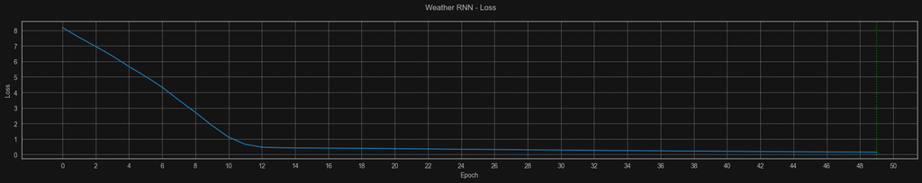

```python
import seaborn as sb

fig, axes = plt.subplots(nrows=1, ncols=1, figsize=(20, 4))


sb.lineplot(loss_history, ax=axes)
axes.set_xticks(range(0, n_epochs + 1, 2))
axes.set_xlabel('Epoch')
axes.set_ylabel('Loss')
axes.axvline(x=best_epoch, color='g', linestyle=':')

plt.suptitle('Weather RNN - Loss')
plt.tight_layout()
```

#### 3.3 - Testing

Similar to training function. This time we run the model with no gradients calculations  
and iterate through batches from test_loader.  
Then return y true and y predicted values to compare where the model makes most mistakes.

```python
from sklearn.metrics import mean_absolute_error

# rescaling back to temperature format.
def return_degrees(y_true, y_pred):
    # because our scaler remembers what did it scale before, we need to create data with same dimensions
    y_true_deg = np.zeros((len(y_true), 3))
    y_true_deg[:, 2] = y_true
    y_true_deg = scaler.inverse_transform(y_true_deg)[:, 2]

    y_pred_deg = np.zeros((len(y_pred), 3))
    y_pred_deg[:, 2] = y_pred
    y_pred_deg = scaler.inverse_transform(y_pred_deg)[:, 2]

    return mean_absolute_error(y_true_deg, y_pred_deg)
```

```python
def test_model(model, device, test_loader, extra_features=False):
    total_loss = 0
    criterion = nn.MSELoss()
    y_true, y_pred = [], []

    with torch.no_grad():
        for batch in test_loader:
            inputs, targets = batch
            inputs, targets = (inputs.to(device).float(),
                               targets.to(device).float())

            if not extra_features:
                inputs = inputs.unsqueeze(-1)

            outputs = model(inputs) # get outputs

            loss = criterion(outputs, targets.unsqueeze(1)) # add dim
            total_loss += loss.item()

            y_true.extend(targets.cpu().numpy())
            y_pred.extend(outputs.cpu().numpy())

    avg_loss = total_loss / len(test_loader)
    print(f"Test MSE Loss: {avg_loss:.4f}")

    return y_true, y_pred, avg_loss
```

```
Test MSE Loss: 0.0100
MAE (in °C) Celsius: 0.720882
```

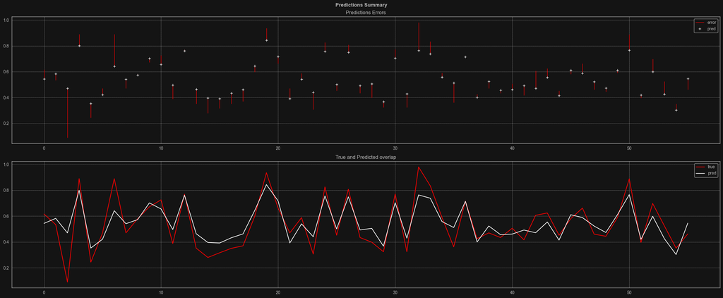

```python
import seaborn as sb

y_true, y_pred, mse = test_model(weather_rnn, device=device, test_loader=test_loader)

fig, axes = plt.subplots(nrows=2, ncols=1, figsize=(24, 10))
axes = axes.flatten()

temp_avg_true = np.array(y_true).flatten()
temp_avg_pred = np.array(y_pred).flatten()

x = range(len(temp_avg_true))
axes[0].vlines(x=x, ymin=temp_avg_pred, ymax=temp_avg_true, color='red', linewidth=1, label='error')
axes[0].plot(x, y_pred, marker='+', linestyle='None', color='white', label='pred')

sb.lineplot(x=range(len(temp_avg_true)), y=temp_avg_true, color='red', ax=axes[1], label='true')
sb.lineplot(x=range(len(temp_avg_pred)), y=temp_avg_pred, color='white', ax=axes[1], label='pred')

axes[0].set_title('Predictions Errors')
axes[0].legend()

axes[1].set_title('True and Predicted overlap')

plt.suptitle('Predictions Summary', fontweight='bold')
plt.tight_layout()

degrees_error = return_degrees(temp_avg_true, temp_avg_pred)
print(f'MAE (in °C) Celsius: {degrees_error:4f}')
```

#### 3.4 - Second model

Now we use 3 features (precipitation, wind, temp_avg) to predict temp_avg.

```python
train_loader_2 = sequence_dataset(df_train_torch, batch_size=batch_size, extra_features=True)
test_loader_2 = sequence_dataset(df_test_torch, batch_size=batch_size, extra_features=True)
```

```python
i = 0
for batch in train_loader_2:
    if i == 0:
        input, target = batch
        # print(input, target)
        print(input.size())
        print(target.size())
        break
    i += 1
```

```
torch.Size([8, 6, 3])
torch.Size([8])
```

```python
weather_rnn_2 = WeatherRNN(input_size=3, # changed inputs size to number of features we pass into the model
                           hidden_size=hidden_size,
                           n_layers=n_layers,
                           output_size=output_size,
                           dropout=dropout)

loss_history_2, best_epoch_2 = train_model(weather_rnn_2, device=device, train_loader=train_loader_2, n_epochs=n_epochs, lr=learning_rate, extra_features=True)
```

```
Epoch 01 / 50 finished | 0.4605
Epoch 10 / 50 finished | 0.0839
Epoch 20 / 50 finished | 0.0219
Epoch 30 / 50 finished | 0.0152
Epoch 40 / 50 finished | 0.0099
Epoch 50 / 50 finished | 0.0074
```

```
Test MSE Loss: 0.0087
MAE (in °C) Celsius: 0.659650
```

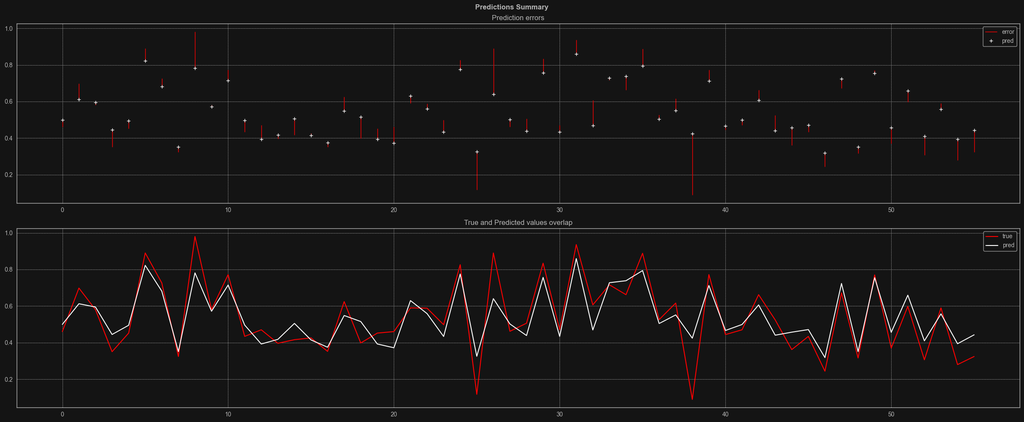

```python
y_true_2, y_pred_2, mse_2 = test_model(weather_rnn_2, device=device, test_loader=test_loader_2, extra_features=True)

fig, axes = plt.subplots(nrows=2, ncols=1, figsize=(24, 10))
axes = axes.flatten()

temp_avg_true_2 = np.array(y_true_2).flatten()
temp_avg_pred_2 = np.array(y_pred_2).flatten()

x = range(len(temp_avg_true_2))
axes[0].vlines(x=x, ymin=temp_avg_pred_2, ymax=temp_avg_true_2, color='red', linewidth=1, label='error')
axes[0].plot(x, y_pred_2, marker='+', linestyle='None', color='white', label='pred')

sb.lineplot(x=range(len(temp_avg_true_2)), y=temp_avg_true_2, color='red', ax=axes[1], label='true')
sb.lineplot(x=range(len(temp_avg_pred_2)), y=temp_avg_pred_2, color='white', ax=axes[1], label='pred')

axes[0].set_title('Prediction errors')
axes[0].legend()

axes[1].set_title('True and Predicted values overlap')

plt.suptitle('Predictions Summary', fontweight='bold')
plt.tight_layout()

degrees_error_2 = return_degrees(temp_avg_true_2, temp_avg_pred_2)
print(f'MAE (in °C) Celsius: {degrees_error_2:4f}')
```

#### 3.5a - Cross-validation for single feature

To test the model on the whole dataset without overfitting we can commit **Cross-Validation**.

```python
# n_folds is number of chunks we split our dataset for
n_folds = 5
df = df.iloc[: (len(df) // n_folds) * n_folds]
step = len(df) // n_folds

df_splits = []

for i in range(0, len(df), step):
    test_chunk = df.iloc[i: i+step] # select certain chunk as test_chunk
    train_chunk = df.drop(df[i: i+step].index) # and then remove the same chunk from train_chunk
    df_splits.append((train_chunk, test_chunk))
```

```python
metrics_1 = {'mae_deg': [], 'mse': []}

# cross-validation
for i, split in enumerate(df_splits):
    train, test = split

    # train loader
    train_torch = train.to_numpy()
    train_torch = torch.tensor(train_torch)
    train_loader = sequence_dataset(train_torch, batch_size=batch_size, extra_features=False)

    # test loader
    test_torch = test.to_numpy()
    test_torch = torch.tensor(test_torch)
    test_loader = sequence_dataset(test_torch, batch_size=batch_size, extra_features=False)

    nth_model = WeatherRNN(input_size=1, hidden_size=hidden_size, n_layers=n_layers, output_size=output_size, dropout=dropout) # define model

    print(f'Fold {i+1} - ', end='')
    train_model(nth_model, device=device, train_loader=train_loader, n_epochs=n_epochs, lr=learning_rate, extra_features=False, verbose=0) # train model

    y_true, y_pred, mse = test_model(nth_model, device=device, test_loader=test_loader, extra_features=False) # test model
    y_true, y_pred = np.array(y_true).flatten(), np.array(y_pred).flatten()

    metrics_1['mse'].append(mse)
    metrics_1['mae_deg'].append(return_degrees(y_true, y_pred))

print(f"Global MSE Loss for {n_folds} folds: {np.mean(metrics_1['mse']):4f}")
print(f"Global MAE (in °C) for {n_folds} folds: {np.mean(metrics_1['mae_deg']):4f}")
```

```
Fold 1 - Test MSE Loss: 0.0081
Fold 2 - Test MSE Loss: 0.0092
Fold 3 - Test MSE Loss: 0.0089
Fold 4 - Test MSE Loss: 0.0101
Fold 5 - Test MSE Loss: 0.0100
Global MSE Loss for 5 folds: 0.009264
Global MAE (in °C) for 5 folds: 0.707501
```

#### 3.5b Cross-validation for multiple features

To test the model with multiple features in cross-validation we simply change **extra_features** boolean value to True in:  
*train_loader*, *test_loader*, *train_model* and *test_model*.  
This will pass all the features (precipitation, wind, temp_avg) to all functions above.

```python
metrics_2 = {'mae_deg': [], 'mse': []}

# cross-validation
for i, split in enumerate(df_splits):
    train, test = split

    # train loader
    train_torch = train.to_numpy()
    train_torch = torch.tensor(train_torch)
    train_loader = sequence_dataset(train_torch, batch_size=batch_size, extra_features=True)

    # test loader
    test_torch = test.to_numpy()
    test_torch = torch.tensor(test_torch)
    test_loader = sequence_dataset(test_torch, batch_size=batch_size, extra_features=True)

    nth_model = WeatherRNN(input_size=3, hidden_size=hidden_size, n_layers=n_layers, output_size=output_size, dropout=dropout) # define model

    print(f'Fold {i+1} - ', end='')
    train_model(nth_model, device=device, train_loader=train_loader, n_epochs=n_epochs, lr=learning_rate, extra_features=True, verbose=0) # train model

    y_true, y_pred, mse = test_model(nth_model, device=device, test_loader=test_loader, extra_features=True) # test model
    y_true, y_pred = np.array(y_true).flatten(), np.array(y_pred).flatten()

    metrics_2['mse'].append(mse)
    metrics_2['mae_deg'].append(return_degrees(y_true, y_pred))

print(f"Global MSE Loss for {n_folds} folds: {np.mean(metrics_2['mse']):4f}")
print(f"Global MAE (in °C) for {n_folds} folds: {np.mean(metrics_2['mae_deg']):4f}")
```

```
Fold 1 - Test MSE Loss: 0.0073
Fold 2 - Test MSE Loss: 0.0089
Fold 3 - Test MSE Loss: 0.0093
Fold 4 - Test MSE Loss: 0.0090
Fold 5 - Test MSE Loss: 0.0085
Global MSE Loss for 5 folds: 0.008606
Global MAE (in °C) for 5 folds: 0.670182
```

#### 3.6 - Comparison

Now we create one DataFrame that contains all information that cross-validation produced.

```python
records = []

# n_features stands for features used to predict temperature (e.g. n_features=3: precip, wind, temp -> temp)
for n_features, data in zip([1, 3], [metrics_1, metrics_2]):
    # data = np.stack(data)
    for fold in range(n_folds):
        records.append({
            'n_features': str(n_features),
            'fold': str(fold),
            'mse': data['mse'][fold],
            'mae_deg': data['mae_deg'][fold]
        })

cross_val_df = pd.DataFrame(records)
```

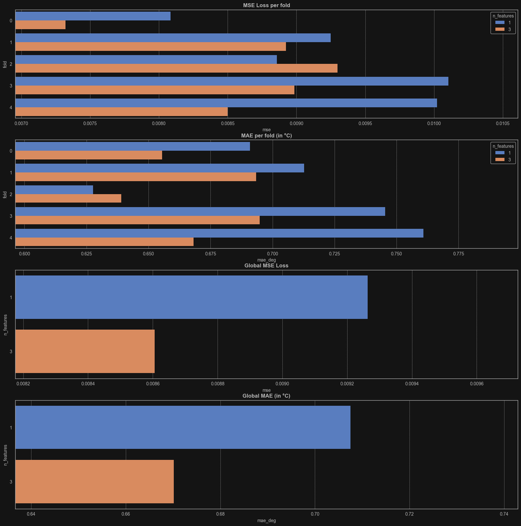

```python
fig, axes = plt.subplots(nrows=4, ncols=1, figsize=(20, 20))
axes = axes.flatten()

mean_df = cross_val_df.drop('fold', axis=1).groupby('n_features').mean().reset_index()

sb.barplot(data=cross_val_df, x='mse', y='fold', hue='n_features', palette="muted", linewidth=0, ax=axes[0])
sb.barplot(data=cross_val_df, x='mae_deg', y='fold', hue='n_features', palette="muted", linewidth=0, ax=axes[1])
sb.barplot(data=mean_df, x='mse', y='n_features', palette="muted", linewidth=0, ax=axes[2])
sb.barplot(data=mean_df, x='mae_deg', y='n_features', palette="muted", linewidth=0, ax=axes[3])

axes[0].set_xlim(cross_val_df['mse'].min()*0.95, cross_val_df['mse'].max()*1.05)
axes[1].set_xlim(cross_val_df['mae_deg'].min()*0.95, cross_val_df['mae_deg'].max()*1.05)
axes[2].set_xlim(mean_df['mse'].min()*0.95, mean_df['mse'].max()*1.05)
axes[3].set_xlim(mean_df['mae_deg'].min()*0.95, mean_df['mae_deg'].max()*1.05)

axes[0].set_title("MSE Loss per fold", fontweight='bold')
axes[1].set_title("MAE per fold (in °C)", fontweight='bold')
axes[2].set_title("Global MSE Loss", fontweight='bold')
axes[3].set_title("Global MAE (in °C)", fontweight='bold')

plt.show()
```

# IV - Conclusion

The chaos in the *precipitation* and *wind* series doesn't seem to provide much valuable information for the model predict the average temperature.  
However, the model that uses 3 features (wind, precipitation and temp_avg) instead of just 1 (temp_avg) got slightly lower loss and error.  
I did tests on different combinations, changing parameters of both the model (hidden_size) and dataset (batch_size, sequence length).  
It turned out that using model with 3 features results in better accuracy of predicting average temperature.  
Overall I think this project gives quiet simple fundamentals to understand the functionality of Recurrent Neural Networks.

#### Thank you for reading my project, I hope you enjoyed the process :]

*- Gracjan Pawłowski, 2025*